# PA1_template

Karolis

11/1/2021

Loading required libraries

```r
library(ggplot2)
library(knitr)
library(dplyr)
```

1. Code for reading in the data set and processing the data:

```r
#importing
raw_data <- read.csv("activity.csv", header = TRUE)

#removing NA
my_data <- raw_data[ with (raw_data, { !(is.na(steps)) } ), ]

#setting as date
my_data$date <- as.Date(as.character(my_data$date), c("%Y-%m-%d"))
```

2. Histogram of the total number of steps taken each day

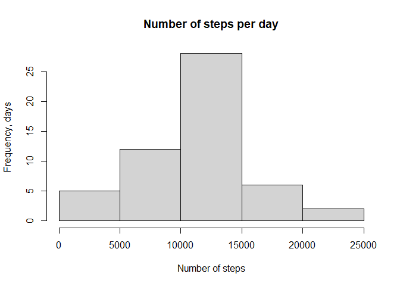

```r
#calculating the sum of each day
steps_sum <- aggregate(steps ~ date,my_data,sum)

hist(steps_sum$steps,main ="Number of steps per day",xlab="Number of steps",ylab="Frequency, days")
```

3a) Median number of steps taken each day:

```r
median(steps_sum$steps)
```

```
## [1] 10765
```

3b) Mean of steps taken each day is:

```r
mean(steps_sum$steps)
```

```
## [1] 10766.19
```

4. Time series plot of the average number of steps taken:

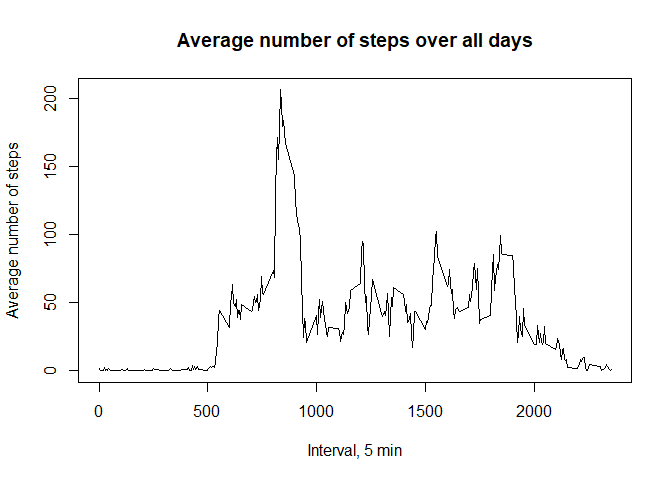

```r
#calculating tre mean for each interval
steps_by_interval <- aggregate(steps ~ interval, my_data, mean)

plot(steps_by_interval$interval, steps_by_interval$steps, type='l',
     main="Average number of steps over all days", xlab="Interval, 5 min",
     ylab="Average number of steps")
```

5. The 5-minute interval that, on average, contains the maximum number of steps:

```r
steps_by_interval[which.max(steps_by_interval$steps), ]
```

```
##     interval    steps
## 104      835 206.1698
```

6. Code to describe and show a strategy for imputing missing data:
1. Total number of missing values in the dataset:

```r
sum(is.na(raw_data))
```

```
## [1] 2304
```

2. changing the missing values to the mean for that 5-minute interval

```r
#replacing NAs with the mean of 5 min interval
my_data_noNA <- raw_data
for (i in 1:nrow(my_data_noNA)) {
  if (is.na(my_data_noNA$steps[i])) {
    interval_value <- my_data_noNA$interval[i]
    steps_value <- steps_by_interval[
      steps_by_interval$interval == interval_value,]
    my_data_noNA$steps[i] <- steps_value$steps
  }
}
```

7. Histogram of the total number of steps taken each day after missing values are imputed:

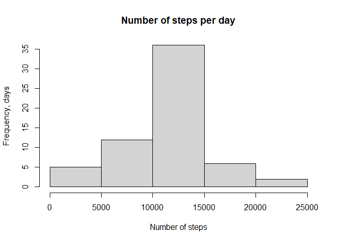

```r
#calculating the total number of steps
steps_sum_noNA <- aggregate(steps ~ date,my_data_noNA,sum)

hist(steps_sum_noNA$steps,main ="Number of steps per day",xlab="Number of steps",ylab="Frequency, days")
```

Median number of steps taken each day with NA is:

```r
median(steps_sum$steps)
```

```
## [1] 10765
```

Median number of steps taken each day without NA is:

```r
median(steps_sum_noNA$steps)
```

```
## [1] 10766.19
```

Mean of steps taken each day with NA is:

```r
mean(steps_sum$steps)
```

```
## [1] 10766.19
```

Mean of steps taken each day without NA is:

```r
mean(steps_sum_noNA$steps)
```

```
## [1] 10766.19
```

Median is slightly different, while mean is the same.

8. Panel plot comparing the average number of steps taken per 5-minute interval across weekdays and weekends
1. Making a list of weekdays and weekends

```r
#making a list of weekdays and weekends
my_data_noNA['type_of_day'] <-weekdays(as.Date(my_data_noNA$date))
my_data_noNA$type_of_day[my_data_noNA$type_of_day %in% c('Saturday','Sunday') ] <- "weekend"
my_data_noNA$type_of_day[my_data_noNA$type_of_day !="weekend" ] <- "weekday"


#seting type_of day as factor
my_data_noNA$type_of_day <- as.factor(my_data_noNA$type_of_day)

#calculating the mean
weekday_weekend_mean <- aggregate(steps ~ interval + type_of_day, my_data_noNA, mean)
```

2. drawing a plot

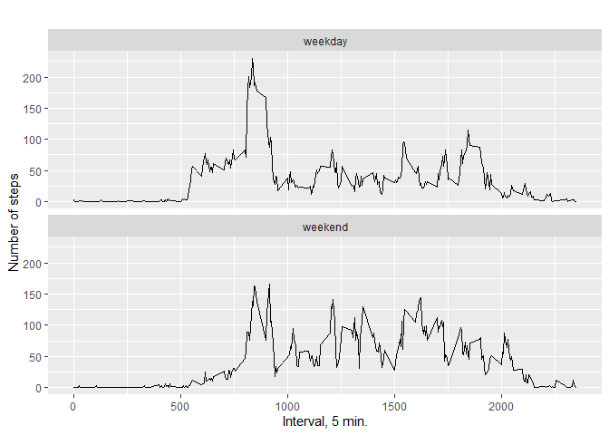

```r
qplot(data = weekday_weekend_mean,
      interval,
      steps,
      type = 'l',
      geom=c("line"),
      xlab = "Interval, 5 min.",
      ylab = "Number of steps",
      main = "") +
  facet_wrap(~ type_of_day, ncol = 1)
```